# Final_Project

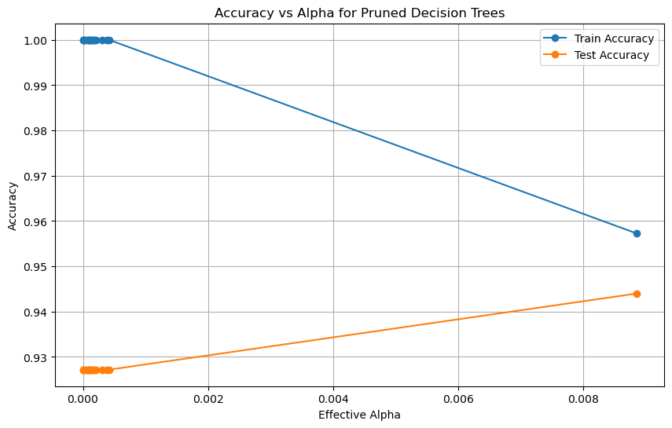

```python
import matplotlib.pyplot as plt
from sklearn.tree import plot_tree, DecisionTreeClassifier
from sklearn.model_selection import cross_val_score
import numpy as np

# Perform cost complexity pruning path
path = best_dt_classifier.cost_complexity_pruning_path(X_train_cls, y_train_cls)
ccp_alphas, impurities = path.ccp_alphas, path.impurities

# Train decision tree with each alpha
clfs = []
for ccp_alpha in ccp_alphas:
    clf = DecisionTreeClassifier(random_state=42, ccp_alpha=ccp_alpha)
    clf.fit(X_train_cls, y_train_cls)
    clfs.append(clf)

# Calculate accuracy for each alpha
train_scores = [clf.score(X_train_cls, y_train_cls) for clf in clfs]
test_scores = [accuracy_score(y_test_cls, clf.predict(X_test_cls)) for clf in clfs]

# Plot the relationship between alpha and accuracy
plt.figure(figsize=(10, 6))
plt.plot(ccp_alphas, train_scores, marker='o', label='Train Accuracy')
plt.plot(ccp_alphas, test_scores, marker='o', label='Test Accuracy')
plt.xlabel('Effective Alpha')
plt.ylabel('Accuracy')
plt.title('Accuracy vs Alpha for Pruned Decision Trees')
plt.legend()
plt.grid(True)
plt.show()
```

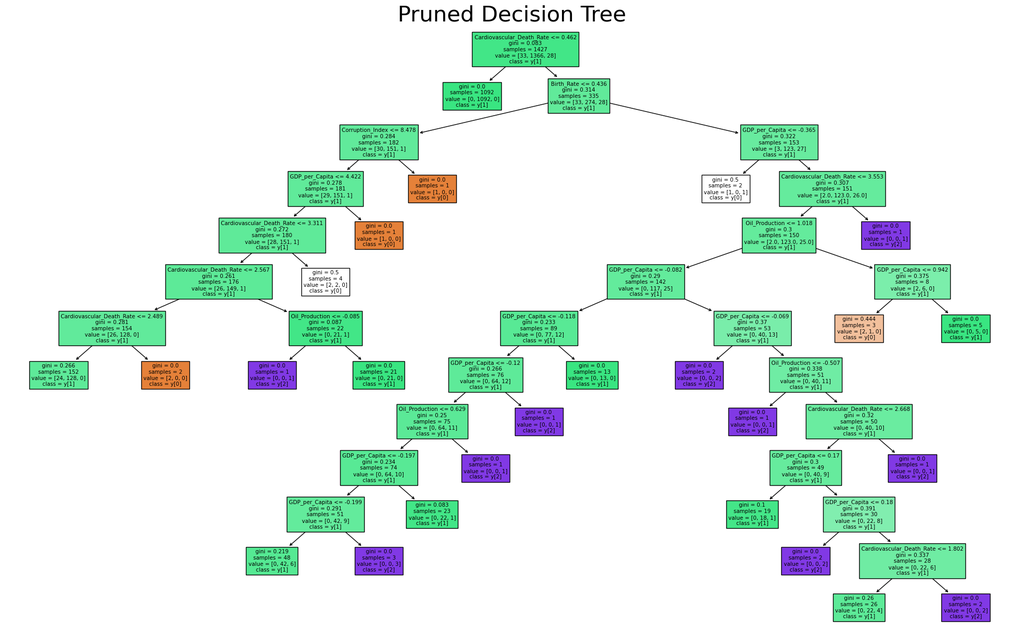

```python
selected_ccp_alpha = 0.001

# Train the pruned decision tree with the selected alpha
pruned_dt_classifier = DecisionTreeClassifier(random_state=42, ccp_alpha=selected_ccp_alpha)
pruned_dt_classifier.fit(X_train_cls, y_train_cls)

# Plot the pruned decision tree
plt.figure(figsize=(25, 15))
plot_tree(pruned_dt_classifier, filled=True, feature_names=X_train_cls.columns, class_names=True)
plt.title("Pruned Decision Tree",fontsize=30)
plt.show()
```

Summary of the Right Side of the Tree The right side of the decision tree focuses on further splitting based on Birth_Rate and GDP_per_Capita after the initial split on Cardiovascular_Death_Rate. The key features involved in this side include Oil_Production and GDP_per_Capita, which are used to refine the classification of samples.

The decision tree prunes branches that do not contribute significantly to reducing impurity (gini index). This pruning process leads to a simpler tree structure, which helps to avoid overfitting and improves generalization to unseen data. The splits help to classify the data into distinct classes, with nodes showing varying degrees of purity as indicated by their gini scores.

### Boosting

```
Best Parameters: {'learning_rate': 0.1, 'n_estimators': 10}
Cross-validation scores: [0.92307692 0.93356643 0.93684211 0.91929825 0.9122807 ]
Mean cross-validation accuracy: 0.93
Classification Accuracy: 0.92
Classification Report:
              precision    recall  f1-score   support

        High       0.20      0.15      0.17        13
         Low       0.95      0.96      0.96       337
      Medium       0.17      0.14      0.15         7

    accuracy                           0.92       357
   macro avg       0.44      0.42      0.43       357
weighted avg       0.91      0.92      0.91       357
```

[figure not shown]

```python
from sklearn.tree import DecisionTreeClassifier
from sklearn.ensemble import AdaBoostClassifier
from sklearn.model_selection import GridSearchCV, cross_val_score
from sklearn.metrics import accuracy_score, classification_report, confusion_matrix
import seaborn as sns
import matplotlib.pyplot as plt

# Initialize the base Decision Tree Classifier
base_dt_classifier = DecisionTreeClassifier(random_state=42)

# Initialize the AdaBoost Classifier
adaboost_classifier = AdaBoostClassifier(estimator=base_dt_classifier, random_state=42)

# Define the parameter grid for GridSearchCV
param_grid = {
    'n_estimators': [10, 50, 100],
    'learning_rate': [0.1, 0.5, 1.0]
}

# Perform GridSearchCV to find the best parameters
grid_search = GridSearchCV(estimator=adaboost_classifier, param_grid=param_grid, cv=5, n_jobs=-1, scoring='accuracy')
grid_search.fit(X_train_cls, y_train_cls)

# Get the best parameters
best_params = grid_search.best_params_
print(f'Best Parameters: {best_params}')

# Train the AdaBoost Classifier with the best parameters
best_adaboost_classifier = grid_search.best_estimator_

# Perform cross-validation
cv_scores = cross_val_score(best_adaboost_classifier, X_train_cls, y_train_cls, cv=5, scoring='accuracy')
print(f'Cross-validation scores: {cv_scores}')
print(f'Mean cross-validation accuracy: {cv_scores.mean():.2f}')

# Fit the best estimator on the entire training data
best_adaboost_classifier.fit(X_train_cls, y_train_cls)

# Predict on the test set
y_pred_cls = best_adaboost_classifier.predict(X_test_cls)

# Calculate and print accuracy
accuracy_boost = accuracy_score(y_test_cls, y_pred_cls)
print(f'Classification Accuracy: {accuracy_boost:.2f}')

# Print classification report
print('Classification Report:')
print(classification_report(y_test_cls, y_pred_cls))

# Confusion matrix
conf_matrix = confusion_matrix(y_test_cls, y_pred_cls)
sns.heatmap(conf_matrix, annot=True, fmt='d', cmap='Blues', xticklabels=labels, yticklabels=labels)
plt.xlabel('Predicted')
plt.ylabel('Actual')
plt.title('Confusion Matrix')
plt.show()
```

### Comparison

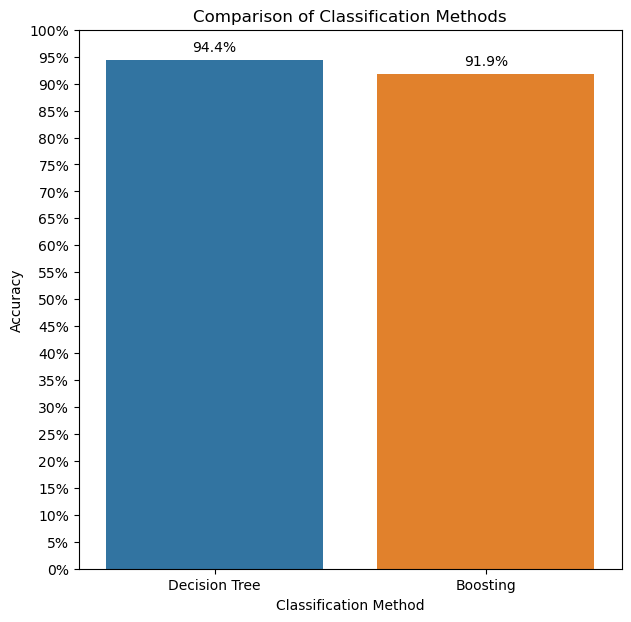

```python
import numpy as np
import matplotlib.pyplot as plt
import seaborn as sns

# Define the classification methods and their respective accuracies
methods = ['Decision Tree', 'Boosting']
accuracies = [ accuracy_dt, accuracy_boost]

# Define the y-axis points with 0.05 distance between each point
y_ticks = np.arange(0, 1.05, 0.05)

plt.figure(figsize=(7,7))
ax = sns.barplot(x=methods, y=accuracies)

# Add accuracy percentages on top of the bars
for p in ax.patches:
    ax.annotate(f'{p.get_height() * 100:.1f}%',
                (p.get_x() + p.get_width() / 2., p.get_height()),
                ha='center', va='center', xytext=(0, 9), textcoords='offset points')

plt.yticks(y_ticks, [f'{int(tick * 100)}%' for tick in y_ticks])
plt.title('Comparison of Classification Methods')
plt.xlabel('Classification Method')
plt.ylabel('Accuracy')
plt.show()
```

### Feature Importance

```python
import matplotlib.pyplot as plt
import seaborn as sns
from sklearn.tree import DecisionTreeClassifier
from sklearn.ensemble import GradientBoostingClassifier

# Train the Decision Tree Classifier
dt_classifier = DecisionTreeClassifier(random_state=42)
dt_classifier.fit(X_train_cls, y_train_cls)
dt_feature_importances = dt_classifier.feature_importances_

# Train the Boosting Classifier
boost_classifier = GradientBoostingClassifier(random_state=42)
boost_classifier.fit(X_train_cls, y_train_cls)
boost_feature_importances = boost_classifier.feature_importances_
```

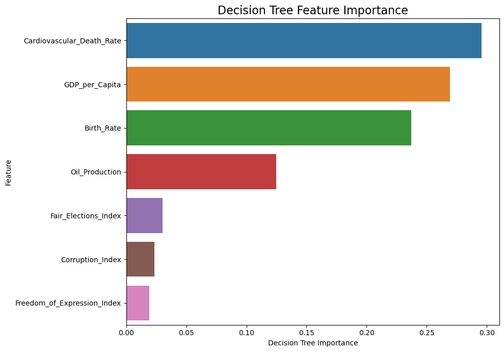

```python
import matplotlib.pyplot as plt
import seaborn as sns
import pandas as pd

# Assuming dt_feature_importances is the feature importances from the decision tree model

# Combine feature importances into a DataFrame
feature_importance_df = pd.DataFrame({
    'Feature': X_train_cls.columns,
    'Decision Tree Importance': dt_feature_importances,
    'Boosting Importance': boost_feature_importances
}).sort_values(by='Boosting Importance', ascending=False)

# Plot the Decision Tree Feature Importance
plt.figure(figsize=(10, 7))
sns.barplot(x='Decision Tree Importance', y='Feature', data=feature_importance_df)
plt.title('Decision Tree Feature Importance', fontsize=16)
plt.tight_layout()
plt.show()
```

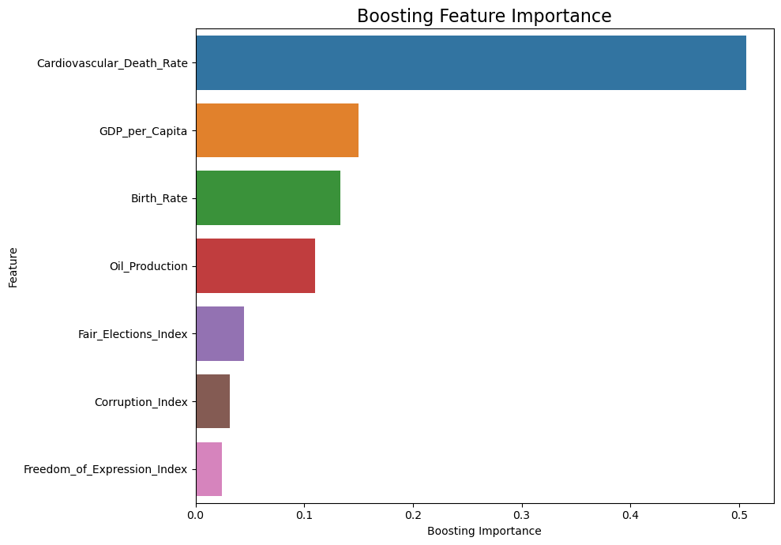

```python
# Plot the Boosting Feature Importance
plt.figure(figsize=(10, 7))
sns.barplot(x='Boosting Importance', y='Feature', data=feature_importance_df)
plt.title('Boosting Feature Importance', fontsize=16)
plt.tight_layout()
plt.show()
```